# Final Exam

Alex Yang

This is an **independent assignment**. Do not discuss or work with classmates.

# Grading Notes

- The exam is graded out of 100 pts.
- 20 points are given for overall style and ease of reading. If you don’t use the homework format or print out pages of unnecessary output the style points will be reduced.
- The point totals for each question are provided below.
- Be sure to show your work so you can get partial credit even if your solution is wrong.

# Required R packages and Directories

```r
data_dir = 'https://mdporter.github.io/teaching/data' # data directory
library(tidyverse) # functions for data manipulation
library(mclust)    # model based clustering
library(mixtools)  # for poisson mixture models
```

# Problem 1: Customer Segmentation (15 pts)

RFM analysis is an approach that some businesses use to understand their customers’ activities. At any point in time, a company can measure how recently a customer purchased a product (Recency), how many times they purchased a product (Frequency), and how much they have spent (Monetary Value). There are many ad-hoc attempts to segment/cluster customers based on the RFM scores (e.g., here is one based on using the customers’ rank of each dimension independently: https://joaocorreia.io/blog/rfm-analysis-increase-sales-by-segmenting-your-customers.html). In this problem you will use the clustering methods we covered in class to segment the customers.

The data for this problem can be found here: <https://mdporter.github.io/teaching/data/RFM.csv\>. Cluster based on the `Recency`, `Frequency`, and `Monetary` features.

## a. Load the data (3 pts)

```r
# loading the data
customer_data = read.csv(file.path(data_dir, "RFM.csv"))
```

```r
# Getting a quick view of the data
str(customer_data)
```

```
## 'data.frame':    10000 obs. of  4 variables:
##  $ id       : int  1 2 3 4 5 6 7 8 9 10 ...
##  $ Recency  : int  139 447 164 120 213 111 286 183 264 165 ...
##  $ Frequency: int  13 10 7 11 13 9 13 8 5 7 ...
##  $ Monetary : int  1147 939 690 1191 996 1005 1290 908 519 947 ...
```

```r
summary(customer_data)
```

```
##        id           Recency        Frequency         Monetary
##  Min.   :    1   Min.   :  2.0   Min.   : 1.000   Min.   :  11.0
##  1st Qu.: 2501   1st Qu.: 88.0   1st Qu.: 8.000   1st Qu.: 683.0
##  Median : 5000   Median :149.0   Median :10.000   Median : 915.0
##  Mean   : 5000   Mean   :181.7   Mean   : 9.814   Mean   : 935.7
##  3rd Qu.: 7500   3rd Qu.:232.0   3rd Qu.:12.000   3rd Qu.:1155.0
##  Max.   :10000   Max.   :953.0   Max.   :24.000   Max.   :2422.0
```

```r
cat("\n Missing data count: \n")
```

```
##
##  Missing data count:
```

```r
colSums(is.na(customer_data))
```

```
##        id   Recency Frequency  Monetary
##         0         0         0         0
```

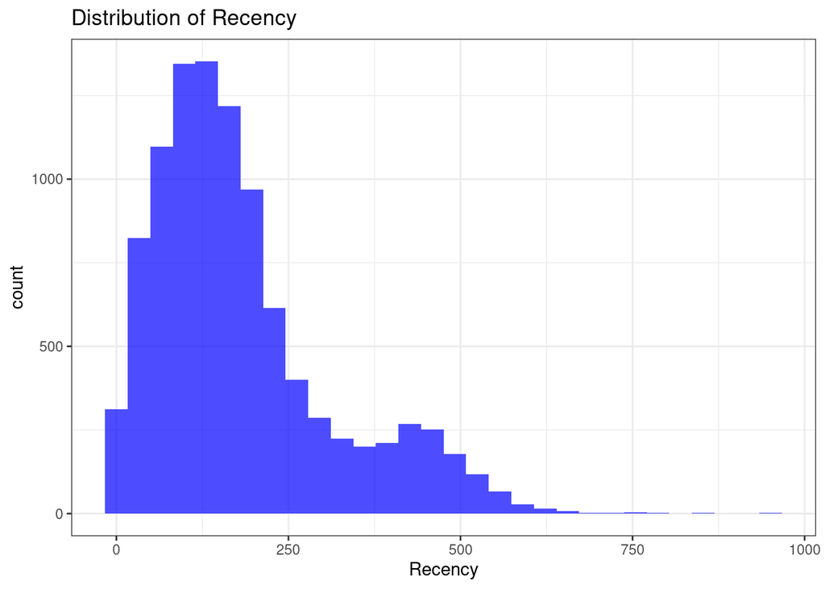

```r
# Visualize the data distribution
ggplot(customer_data, aes(x = Recency)) +
  geom_histogram(bins = 30, fill = "blue", alpha = 0.7) +
  ggtitle("Distribution of Recency")
```

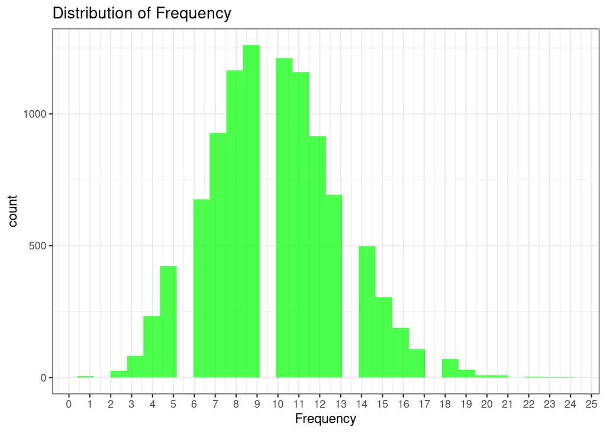

```r
ggplot(customer_data, aes(x = Frequency)) +
  geom_histogram(bins = 30, fill = "green", alpha = 0.7) +
  scale_x_continuous(breaks = seq(0,25, by =1))+
  ggtitle("Distribution of Frequency")
```

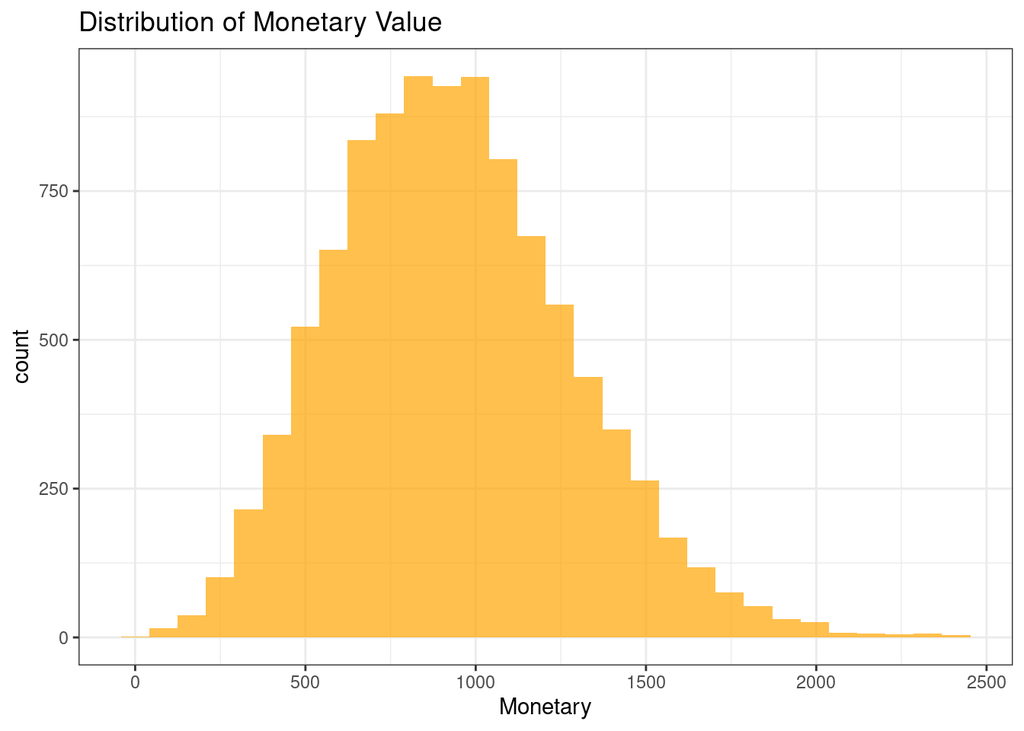

```r
ggplot(customer_data, aes(x = Monetary)) +
  geom_histogram(bins = 30, fill = "orange", alpha = 0.7) +
  ggtitle("Distribution of Monetary Value")
```

## b. Implement hierarchical clustering. (3 pts)

- Describe any pre-processing steps you took (e.g., scaling, distance metric)
- State the linkage method you used with justification.
- Show the resulting dendrogram.
- State the number of segments/clusters you used with justification.
- Using your segmentation, are customers 1 and 12 in the same cluster?

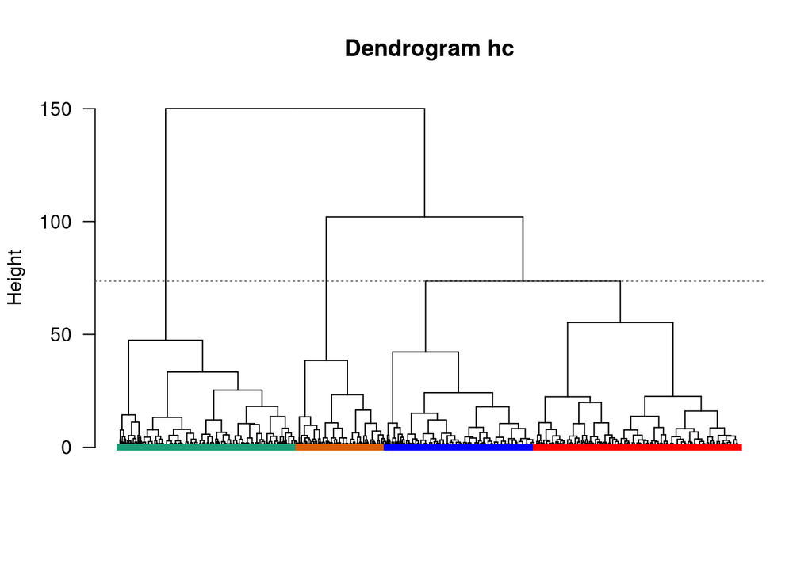

```r
# Step 1: Pre-processing
#   Scaling the data
scaled_data <- customer_data %>%
  select(-id) %>%    # Remove the 'id' column
  scale()            # Scale the remaining columns

#   Distance Metric (Euclidean distance)
distance_matrix <- dist(scaled_data, method = "euclidean")



# Step 2: Linkage method
hclust_model <- hclust(distance_matrix, method = "ward.D2")
hc <- hclust(distance_matrix, method = "ward.D2")
# Justification: I used ward.d2 method because it minimizes the total within cluster variance. Since we are trying to understand the customer's activities we don't want to have too many small groups. Ward's linkage would produce clusters of roughly similar sizes avoiding small clusters being merged into large ones prematurely as well. Ward's linkage works very well with numerical data too and we aim to minimize variance in this particular problem.



# Step 3: show the resulting denodrogram
colPalette <- c('#1b9e77', '#d95f02', 'red', 'blue', '#66a61e')

#   Cut the dendrogram into clusters (example: k = 4)
clusters <- cutree(hc, k = 4)

#   Plot the dendrogram
plot(as.dendrogram(hc),
     las = 1,
     leaflab = "none",
     ylab = "Height",
     main = "Dendrogram hc")

#   Order and customize points below the dendrogram
ord <- hc$order
labels <- clusters[ord]
colors <- colPalette[labels]
shapes <- 15
n <- length(labels)

#   Add points below the dendrogram
points(1:n, rep(0, n), col = colors, pch = shapes, cex = 0.8)

# Calculating the eblow data
# Calculate merge heights and cluster numbers
elbow_data <- tibble(
  height = rev(hc$height),               # Heights of merges (reversed)
  K = seq_along(hc$height) + 1          # Cluster numbers (2 to n)
)

#   Add a horizontal line at k==4$height to indicate clusters
abline(h = filter(elbow_data, K==4)$height, lty = 3, col = "grey40")
```

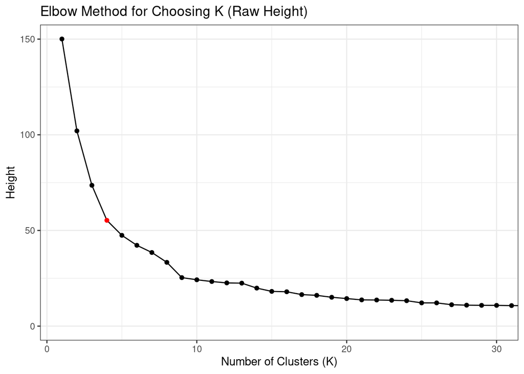

```r
# Step 4: Number of Segments
#   Calculate merge heights and cluster numbers
elbow_data <- tibble(
  height = hc$height,               # Heights of merges
  K = row_number(-hc$height)       # Cluster numbers (reverse order)
)

#   Plot the elbow method graph (raw height)
elbow_data %>%
  ggplot(aes(K, height)) +
  geom_line() +
  geom_point(aes(color = ifelse(K == 4, "red", "black"))) +
  scale_color_identity() +
  coord_cartesian(xlim = c(1, 30)) +
  labs(title = "Elbow Method for Choosing K (Raw Height)",
       x = "Number of Clusters (K)",
       y = "Height")
```

```r
# Explanation: I used the elbow method and I generate a graph to see the height when there is a large jump in the height it indicates that merging those clusters caused a significant loss of cluster compactness. The optimal k or the k I chose in this situation is located right before the big jump.



# Step 5: Are Customer 1 and 12 in the same cluster?
clusters <- cutree(hc, k = 4)
#   Check the cluster assignments for Customer 1 and Customer 12
clusters[1] == clusters[12]
```

```
## [1] TRUE
```

```r
cat("Customer 1 and 12 are in the same cluster")
```

```
## Customer 1 and 12 are in the same cluster
```

## c. Implement k-means. (3 pts)

- Describe any pre-processing steps you took (e.g., scaling)
- State the number of segments/clusters you used with justification.
- Using your segmentation, are customers 1 and 12 in the same cluster?

```r
# Step 1: Pre-processing (sclaing the data)
scaled_data <- scale(customer_data %>% select(-id))

#   Outlier detection by Mahalanobis Distance
mahal_dist <- mahalanobis(scaled_data, colMeans(scaled_data), cov(scaled_data))
threshold <- qchisq(0.99, df = ncol(scaled_data)) #set threashold using chi-squared distribution
outliers <- which(mahal_dist > threshold)  # identify outlier based on threashold
scaled_data_clean <- scaled_data[-outliers, ] # deleting outliers from data

# Step 2: number of segments
#   Calculate WCSS for different numbers of clusters
wcss <- sapply(1:10, function(k) {
  set.seed(123)
  kmeans(scaled_data, centers = k, nstart = 25)$tot.withinss
})
```

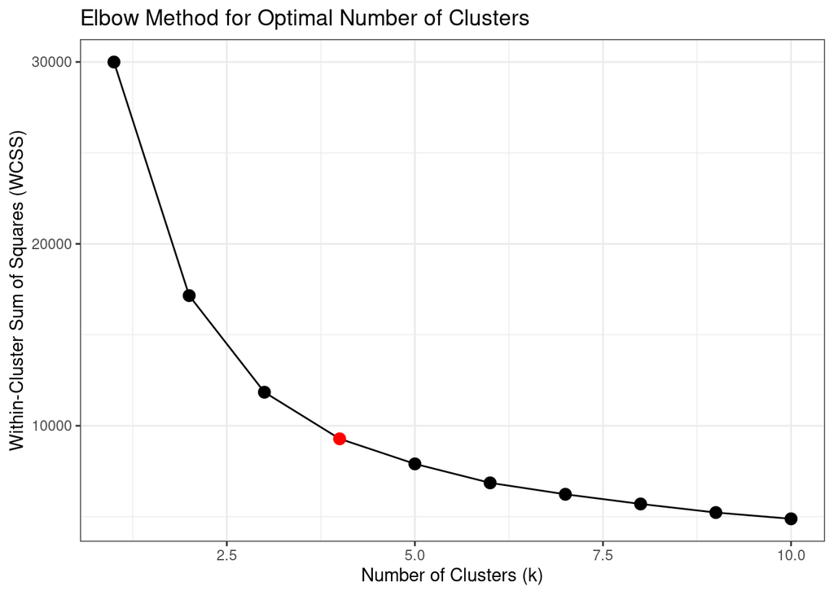

```r
#   Plot the Elbow Method
wcss_data <- tibble(
  k = 1:10,
  wcss = wcss
)

ggplot(wcss_data, aes(x = k, y = wcss)) +
  geom_line() +
  geom_point(aes(color = ifelse(k == 4, "red", "black")), size = 3) +  # Highlight k=4
  scale_color_identity() +
  labs(
    title = "Elbow Method for Optimal Number of Clusters",
    x = "Number of Clusters (k)",
    y = "Within-Cluster Sum of Squares (WCSS)"
  )
```

```r
# Justification:

# Step 3: Implement k-means clustering
kmeans_model <- kmeans(scaled_data, centers = 4, nstart = 25, iter.max = 3000)
kmeans_clusters <- kmeans_model$cluster # getting cluster assignment for each customer

# Step 4: customer 1 and 12 clustering?
cat('customer 1 and 12 are not in the same cluster group')
```

[output not shown]

```
## customer 1 and 12 are not in the same cluster group
```

```r
kmeans_clusters[1] == kmeans_clusters[12]
```

```
## [1] FALSE
```